# OYO Machine Learning Project

[figure not shown]

## OYO Machine Learning Project

#### Project Notebook : **PRASAD JADHAV**

```python
import pandas as pd
import numpy as np

import matplotlib.pyplot as plt
import seaborn as sns
```

```python
import warnings
warnings.filterwarnings('ignore')
```

```python
# Load Dataset
file_path = 'oyo_dataset.csv'
df = pd.read_csv(file_path)
pd.set_option('display.max_columns',30)
print(df.shape)
```

```
(100000, 28)
```

```python
df.head()
```

|  | Date | Hotel_ID | Room_Type | City | Season | Day_of_Week | Is_Holiday | Events | Lead_Time | Previous_Cancellations | Previous_Stays | Room_Price | Customer_Type | Market_Segment | Weather | Competitor_Price | Occupancy_Rate | Weekend | Loyalty_Points | Customer_Rating | Hotel_Rating | Distance_to_City_Center | Promotional_Offer | Cancellation_Policy | Booking_Channel | Competitor_Occupancy_Rate | Seasonal_Discount | Customer_Age_Group |
| --- | --- | --- | --- | --- | --- | --- | --- | --- | --- | --- | --- | --- | --- | --- | --- | --- | --- | --- | --- | --- | --- | --- | --- | --- | --- | --- | --- | --- |
| 0 | 2023-01-01 00:00:00 | 39 | Single | Hyderabad | Summer | 6 | 0 | 0 | 20 | 4 | 4 | 242.437789 | Regular | Offline | Rainy | 61.693887 | 0.616151 | 0 | 8545 | 2.747594 | 4.735215 | 7.157745 | 0 | Strict | Third-Party | 0.100518 | 27.348245 | 46-60 |
| 1 | 2023-01-01 00:01:00 | 29 | Single | Chennai | Spring | 6 | 0 | 1 | 62 | 1 | 1 | 188.743477 | New | Online | Cloudy | 230.223895 | 0.900158 | 1 | 9905 | 3.072013 | 1.304658 | 3.356201 | 1 | Strict | Third-Party | 0.569342 | 29.094011 | 18-25 |
| 2 | 2023-01-01 00:02:00 | 15 | Single | Delhi | Spring | 6 | 1 | 0 | 88 | 2 | 8 | 160.069709 | Returning | Offline | Sunny | 450.944803 | 0.771130 | 0 | 2682 | 1.521841 | 2.919828 | 12.142134 | 0 | Flexible | Mobile App | 0.056891 | 27.892858 | 60+ |
| 3 | 2023-01-01 00:03:00 | 43 | Suite | Bangalore | Spring | 6 | 1 | 0 | 24 | 3 | 9 | 73.607886 | Regular | Offline | Sunny | 286.027554 | 0.968814 | 1 | 9889 | 3.116169 | 3.763586 | 16.735215 | 0 | Moderate | Third-Party | 0.165711 | 42.227849 | 18-25 |
| 4 | 2023-01-01 00:04:00 | 8 | Suite | Mumbai | Winter | 6 | 1 | 1 | 55 | 0 | 5 | 455.353827 | New | Offline | Sunny | 323.303646 | 0.604268 | 1 | 6230 | 1.257365 | 4.900125 | 10.895326 | 0 | Moderate | Third-Party | 0.947143 | 27.735535 | 60+ |

```python
df.tail()
```

|  | Date | Hotel_ID | Room_Type | City | Season | Day_of_Week | Is_Holiday | Events | Lead_Time | Previous_Cancellations | Previous_Stays | Room_Price | Customer_Type | Market_Segment | Weather | Competitor_Price | Occupancy_Rate | Weekend | Loyalty_Points | Customer_Rating | Hotel_Rating | Distance_to_City_Center | Promotional_Offer | Cancellation_Policy | Booking_Channel | Competitor_Occupancy_Rate | Seasonal_Discount | Customer_Age_Group |
| --- | --- | --- | --- | --- | --- | --- | --- | --- | --- | --- | --- | --- | --- | --- | --- | --- | --- | --- | --- | --- | --- | --- | --- | --- | --- | --- | --- | --- |
| 99995 | 2023-03-11 10:35:00 | 48 | Double | Chennai | Spring | 5 | 1 | 1 | 82 | 4 | 4 | 383.255632 | Regular | Online | Cloudy | 240.954722 | 0.998714 | 1 | 3944 | 2.276480 | 3.863507 | 19.732693 | 1 | Strict | Third-Party | 0.382503 | 13.790094 | 26-35 |
| 99996 | 2023-03-11 10:36:00 | 44 | Double | Chennai | Summer | 5 | 0 | 1 | 59 | 0 | 9 | 183.509331 | New | Offline | Rainy | 404.268867 | 0.001841 | 0 | 5574 | 4.224502 | 3.020554 | 10.819728 | 0 | Moderate | Mobile App | 0.906176 | 23.338111 | 60+ |
| 99997 | 2023-03-11 10:37:00 | 19 | Double | Bangalore | Spring | 5 | 0 | 0 | 80 | 0 | 9 | 426.436482 | New | Offline | Sunny | 68.018693 | 0.280539 | 0 | 682 | 1.845448 | 1.791473 | 19.283274 | 0 | Moderate | Third-Party | 0.155378 | 0.108545 | 36-45 |
| 99998 | 2023-03-11 10:38:00 | 20 | Single | Hyderabad | Autumn | 5 | 0 | 1 | 72 | 3 | 6 | 204.541477 | Regular | Offline | Sunny | 498.772111 | 0.204033 | 1 | 3191 | 4.212645 | 2.524861 | 19.798426 | 0 | Strict | Third-Party | 0.783196 | 48.803788 | 36-45 |
| 99999 | 2023-03-11 10:39:00 | 15 | Suite | Hyderabad | Winter | 5 | 1 | 0 | 85 | 1 | 5 | 52.369881 | Returning | Offline | Cloudy | 299.458830 | 0.437643 | 0 | 3051 | 3.461413 | 4.616820 | 2.580137 | 0 | Strict | Third-Party | 0.919288 | 33.223667 | 60+ |

#### Objective

- Build a machine learning model to predict the occupancy rate of OYO rooms based on historical data and various features.

#### Features

Here are some features that could be included in the dataset:

- Date: The date of the booking.
- Hotel_ID: Unique identifier for each hotel.
- Room_Type: Type of room (e.g., Single, Double, Suite).
- City: The city where the hotel is located.
- Season: The season during the booking (e.g., Summer, Winter).
- Day_of_Week: The day of the week of the booking.
- Is_Holiday: Whether the booking date is a holiday (boolean).
- Events: Whether there are any major events happening in the city (e.g., festivals, conferences).
- Lead_Time: The number of days between the booking date and the check-in date.
- Previous_Cancellations: The number of previous cancellations by the customer.
- Previous_Stays: The number of previous stays by the customer.
- Room_Price: The price of the room.
- Customer_Type: Type of customer (e.g., Regular, New, Returning).
- Market_Segment: The market segment of the booking (e.g., Online, Offline).
- Weather: Weather conditions on the check-in date.
- Competitor_Price: Average room price of competitors in the area.
- Occupancy_Rate: Target variable indicating the occupancy rate (0-1).
- Weekend: Whether the booking date falls on a weekend (boolean).
- Loyalty_Points: Number of loyalty points the customer has accumulated.
- Customer_Rating: Average rating given by the customer for past stays.
- Hotel_Rating: Rating of the hotel.
- Distance_to_City_Center: Distance of the hotel from the city center (in km).
- Promotional_Offer: Whether there was a promotional offer applied (boolean).
- Cancellation_Policy: Type of cancellation policy (e.g., Flexible, Moderate, Strict).
- Booking_Channel: The channel through which the booking was made (e.g., Website, Mobile App, Third-Party).
- Competitor_Occupancy_Rate: Average occupancy rate of competitors in the area.
- Seasonal_Discount: Seasonal discount applied to the booking (percentage).
- Customer_Age_Group: Age group of the customer (e.g., 18-25, 26-35, 36-45, 46-60, 60+).

### Data Exploration

```python
df.info()
```

```
<class 'pandas.core.frame.DataFrame'>
RangeIndex: 100000 entries, 0 to 99999
Data columns (total 28 columns):
 #   Column                     Non-Null Count   Dtype
---  ------                     --------------   -----
 0   Date                       100000 non-null  object
 1   Hotel_ID                   100000 non-null  int64
 2   Room_Type                  100000 non-null  object
 3   City                       100000 non-null  object
 4   Season                     100000 non-null  object
 5   Day_of_Week                100000 non-null  int64
 6   Is_Holiday                 100000 non-null  int64
 7   Events                     100000 non-null  int64
 8   Lead_Time                  100000 non-null  int64
 9   Previous_Cancellations     100000 non-null  int64
```

[output cut: 20 more lines]

```python
df.isnull().sum()
```

```
Date                         0
Hotel_ID                     0
Room_Type                    0
City                         0
Season                       0
Day_of_Week                  0
Is_Holiday                   0
Events                       0
Lead_Time                    0
Previous_Cancellations       0
Previous_Stays               0
Room_Price                   0
Customer_Type                0
Market_Segment               0
Weather                      0
Competitor_Price             0
Occupancy_Rate               0
Weekend                      0
Loyalty_Points               0
Customer_Rating              0
Hotel_Rating                 0
Distance_to_City_Center      0
Promotional_Offer            0
Cancellation_Policy          0
Booking_Channel              0
Competitor_Occupancy_Rate    0
Seasonal_Discount            0
Customer_Age_Group           0
dtype: int64
```

```python
df.duplicated().sum()
```

```
0
```

```python
df.describe()
```

|  | Hotel_ID | Day_of_Week | Is_Holiday | Events | Lead_Time | Previous_Cancellations | Previous_Stays | Room_Price | Competitor_Price | Occupancy_Rate | Weekend | Loyalty_Points | Customer_Rating | Hotel_Rating | Distance_to_City_Center | Promotional_Offer | Competitor_Occupancy_Rate | Seasonal_Discount |
| --- | --- | --- | --- | --- | --- | --- | --- | --- | --- | --- | --- | --- | --- | --- | --- | --- | --- | --- |
| count | 100000.000000 | 100000.000000 | 100000.000000 | 100000.000000 | 100000.000000 | 100000.000000 | 100000.000000 | 100000.000000 | 100000.000000 | 100000.000000 | 100000.000000 | 100000.00000 | 100000.000000 | 100000.000000 | 100000.000000 | 100000.000000 | 100000.000000 | 100000.000000 |
| mean | 25.018140 | 2.984000 | 0.496940 | 0.500350 | 49.910700 | 2.001060 | 4.493050 | 274.959102 | 274.776952 | 0.500241 | 0.502850 | 5004.83050 | 2.997710 | 2.998301 | 10.220422 | 0.498860 | 0.500822 | 24.951076 |
| std | 14.111291 | 1.999946 | 0.499993 | 0.500002 | 28.580682 | 1.412076 | 2.871326 | 129.860025 | 129.982071 | 0.288927 | 0.499994 | 2889.35828 | 1.155805 | 1.150307 | 5.629331 | 0.500001 | 0.289160 | 14.433602 |
| min | 1.000000 | 0.000000 | 0.000000 | 0.000000 | 1.000000 | 0.000000 | 0.000000 | 50.010224 | 50.001144 | 0.000007 | 0.000000 | 0.00000 | 1.000020 | 1.000013 | 0.500203 | 0.000000 | 0.000030 | 0.000237 |
| 25% | 13.000000 | 1.000000 | 0.000000 | 0.000000 | 25.000000 | 1.000000 | 2.000000 | 162.936971 | 161.673269 | 0.250161 | 0.000000 | 2502.75000 | 1.995381 | 2.010447 | 5.333834 | 0.000000 | 0.250383 | 12.453999 |
| 50% | 25.000000 | 3.000000 | 0.000000 | 1.000000 | 50.000000 | 2.000000 | 4.000000 | 274.611333 | 274.743431 | 0.500321 | 1.000000 | 5003.50000 | 2.993468 | 2.995547 | 10.239608 | 0.000000 | 0.500800 | 24.930844 |
| 75% | 37.000000 | 5.000000 | 1.000000 | 1.000000 | 75.000000 | 3.000000 | 7.000000 | 387.742036 | 387.012395 | 0.750986 | 1.000000 | 7500.00000 | 3.996562 | 3.993988 | 15.081360 | 1.000000 | 0.752229 | 37.473246 |
| max | 49.000000 | 6.000000 | 1.000000 | 1.000000 | 99.000000 | 4.000000 | 9.000000 | 499.997718 | 499.990045 | 0.999991 | 1.000000 | 9999.00000 | 4.999945 | 4.999831 | 19.999907 | 1.000000 | 0.999991 | 49.998760 |

```python
cat_cols = [x for x in df.columns if df[x].dtypes != 'float64']

for col in cat_cols:
    print(f"Value counts for column '{col}':")
    print(df[col].value_counts())
    print("\n" + "_"*40 + "\n")
```

```
Value counts for column 'Date':
Date
2023-01-01 00:00:00    1
2023-02-16 06:50:00    1
2023-02-16 07:12:00    1
2023-02-16 07:11:00    1
2023-02-16 07:10:00    1
                      ..
2023-01-24 03:31:00    1
2023-01-24 03:30:00    1
2023-01-24 03:29:00    1
2023-01-24 03:28:00    1
2023-03-11 10:39:00    1
Name: count, Length: 100000, dtype: int64

________________________________________

Value counts for column 'Hotel_ID':
Hotel_ID
36    2126
23    2123
26    2120
45    2116
48    2114
17    2110
30    2107
38    2099
29    2094
21    2093
28    2091
44    2089
5     2085
32    2075
10    2071
15    2071
18    2070
2     2069
13    2069
22    2061
42    2061
```

[output cut: 207 more lines]

```
Mobile App     33028
Name: count, dtype: int64

________________________________________

Value counts for column 'Customer_Age_Group':
Customer_Age_Group
60+      20077
36-45    20027
26-35    19983
46-60    19972
18-25    19941
Name: count, dtype: int64

________________________________________
```

```python
num_cols = [x for x in df.columns if df[x].dtypes == 'float64']

for col in num_cols:
    print(f"Value counts for column '{col}':")
    print(df[col].value_counts())
    print("\n" + "_"*40 + "\n")
```

```
Value counts for column 'Room_Price':
Room_Price
242.437789    1
474.236613    1
491.686290    1
157.972906    1
109.240628    1
             ..
392.308986    1
493.744909    1
381.402627    1
69.994702     1
52.369881     1
Name: count, Length: 100000, dtype: int64

________________________________________

Value counts for column 'Competitor_Price':
Competitor_Price
61.693887     1
259.808885    1
474.508159    1
259.297482    1
167.675536    1
             ..
289.269600    1
399.017106    1
112.747791    1
362.812286    1
299.458830    1
Name: count, Length: 100000, dtype: int64

________________________________________

Value counts for column 'Occupancy_Rate':
Occupancy_Rate
0.616151    1
0.591271    1
0.752604    1
0.326932    1
```

[output cut: 80 more lines]

```
Seasonal_Discount
27.348245    1
17.920371    1
7.992934     1
47.839751    1
17.398256    1
            ..
21.355560    1
18.708858    1
9.083504     1
43.146724    1
33.223667    1
Name: count, Length: 100000, dtype: int64

________________________________________
```

### EDA

```python
num_features = df.select_dtypes(include = ['int64', 'float64']).dtypes.index
```

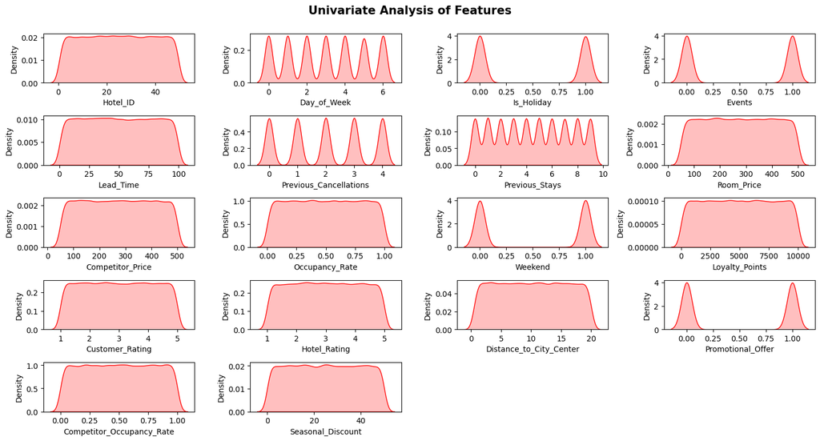

```python
plt.figure(figsize=(15,15))
plt.suptitle('Univariate Analysis of Features',fontweight='bold',fontsize=15,y=1)

for i in range(0,len(num_features)):
    plt.subplot(10,4,i+1)
    sns.kdeplot(x=df[num_features[i]],shade=True,color='#FF0000')
    plt.tight_layout()
```

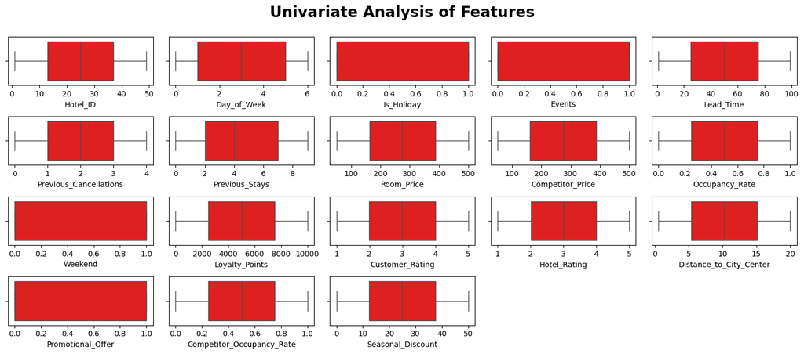

```python
plt.figure(figsize = (15,15))
plt.suptitle('Univariate Analysis of Features',fontweight='bold',fontsize=20,y=1)

for i in range(0,len(num_features)):
    plt.subplot(10,5,i+1)
    sns.boxplot(data=df,x=num_features[i],color='#FF0000')
    plt.xlabel(num_features[i])
    plt.tight_layout()
```

```python
cat_features = df.select_dtypes(include='object').dtypes.index
```

```python
plt.figure(figsize=(15,15))
plt.suptitle('Univariate Analysis of Features',fontweight='bold',fontsize=15,y=1)

for i in range(0,len(cat_features)):
    plt.subplot(10,4,i+1)
    sns.countplot(x=df[cat_features[i]],color='#FF0000')
    plt.tight_layout()
```

[output not shown]

### Feature Preprocessing

```python
# Code for Mapping Function

# Define mapping dictionaries
mapping_dict = {
    "Room_Type": {"Single": 1, "Double": 2, "Suite": 3},
    "City": {"Delhi": 1, "Mumbai": 2, "Bangalore": 3, "Hyderabad": 4, "Chennai": 5},
    "Season": {"Summer": 1, "Winter": 2, "Spring": 3, "Autumn": 4},
    "Customer_Type": {"Regular": 1, "New": 2, "Returning": 3},
    "Market_Segment": {"Online": 1, "Offline": 2},
    "Weather": {"Sunny": 1, "Rainy": 2, "Cloudy": 3},
    "Cancellation_Policy": {"Flexible": 1, "Moderate": 2, "Strict": 3},
    "Booking_Channel": {"Website": 1, "Mobile App": 2, "Third-Party": 3},
}
```

```python
# Apply mapping to the specified columns
for column, mapping in mapping_dict.items():
    if column in df.columns:
        df[column] = df[column].map(mapping)
```

##### Code for Mapping Customer_Age_Group Column

```python
# Define the mapping dictionary for Customer_Age_Group
age_group_mapping = {
    "18-25": 1,
    "26-35": 2,
    "36-45": 3,
    "46-60": 4,
    "60+": 5
}
```

```python
# Apply mapping to the Customer_Age_Group column
if 'Customer_Age_Group' in df.columns:
    df['Customer_Age_Group'] = df['Customer_Age_Group'].map(age_group_mapping)
```

### Occupancy Rate Prediction (Regression)

- Predict the occupancy rate based on features like room type, city, season, lead time, room price, etc.

```python
from sklearn.model_selection import train_test_split
from sklearn.preprocessing import OneHotEncoder, StandardScaler
from sklearn.compose import ColumnTransformer
from sklearn.pipeline import Pipeline
from sklearn.ensemble import RandomForestRegressor
from sklearn.metrics import mean_absolute_error, r2_score
```

```python
# Define features and target variable
X = df.drop(columns=['Occupancy_Rate', 'Date'])
y = df['Occupancy_Rate']
```

```python
# Train-test split
X_train, X_test, y_train, y_test = train_test_split(X, y, test_size=0.2, random_state=42)
```

```python
# Model training
occupancy_model = RandomForestRegressor(n_estimators=100, random_state=42, n_jobs=-1)
occupancy_model.fit(X_train, y_train)
```

```
RandomForestRegressor(n_jobs=-1, random_state=42)
```

```python
# Evaluate the model
y_pred = occupancy_model.predict(X_test)
mae = mean_absolute_error(y_test, y_pred)
r2 = r2_score(y_test, y_pred)

print(f"Mean Absolute Error: {mae}")
print(f"R² Score: {r2}")
```

```
Mean Absolute Error: 0.251060303228306
R² Score: -0.012831170332013864
```

```python
# Define features and target
features = ['Room_Type', 'City', 'Season', 'Day_of_Week', 'Is_Holiday', 'Events', 'Lead_Time', 'Previous_Cancellations',
           'Previous_Stays', 'Room_Price', 'Customer_Type', 'Market_Segment', 'Weather', 'Customer_Rating', 'Hotel_Rating', 'Seasonal_Discount', 'Customer_Age_Group']
target = 'Occupancy_Rate'
```

```python
# Split data into training and testing sets
X_train, X_test, y_train, y_test = train_test_split(df[features], df[target], test_size=0.2, random_state=42)
```

```python
# Model training
base_model = RandomForestRegressor(n_estimators=100, random_state=42, n_jobs=-1)
base_model.fit(X_train, y_train)
```

```
RandomForestRegressor(n_jobs=-1, random_state=42)
```

```python
# Evaluate the model
y_pred = base_model.predict(X_test)
mae = mean_absolute_error(y_test, y_pred)
r2 = r2_score(y_test, y_pred)

print(f"Mean Absolute Error: {mae}")
print(f"R² Score: {r2}")
```

```
Mean Absolute Error: 0.2513988812337191
R² Score: -0.017385918659655664
```

```python
# Prompting user for input
print("Enter the OYO Room Details")

# Input variables with clear prompts
Room_Type = int(input("Enter the Room Type (e.g., 1 for Single, 2 for Double, etc.): "))
City = int(input("Enter the City Code (e.g., 1 for Delhi, 2 for Mumbai, etc.): "))
Season = int(input("Enter the Season (e.g., 1 for Winter, 2 for Summer, etc.): "))
Day_of_Week = int(input("Enter the Day of the Week (1 for Monday to 7 for Sunday): "))
Is_Holiday = int(input("Is it a Holiday? (1 for Yes, 0 for No): "))
Events = int(input("Enter the Event Code (e.g., 1 for Wedding, 2 for Conference, etc.): "))
Lead_Time = int(input("Enter the Lead Time (days before booking): "))
Previous_Cancellations = int(input("Enter the Number of Previous Cancellations: "))
Previous_Stays = int(input("Enter the Number of Previous Stays: "))
Room_Price = float(input("Enter the Room Price: "))
Customer_Type = int(input("Enter the Customer Type (e.g., 1 for Regular, 2 for Corporate, etc.): "))
Market_Segment = int(input("Enter the Market Segment Code: "))
Weather = int(input("Enter the Weather Condition (e.g., 1 for Clear, 2 for Rainy, etc.): "))
Customer_Rating = float(input("Enter the Customer Rating (1-5): "))
Hotel_Rating = float(input("Enter the Hotel Rating (1-5): "))
Seasonal_Discount = float(input("Enter the Seasonal Discount (as a percentage): "))
Customer_Age_Group = int(input("Enter the Customer Age Group (e.g., 1 for 18-25, 2 for 26-40, etc.): "))

# Structuring the input into a numpy array
input_point = np.array([[
    Room_Type, City, Season, Day_of_Week, Is_Holiday, Events, Lead_Time, Previous_Cancellations,
    Previous_Stays, Room_Price, Customer_Type, Market_Segment, Weather, Customer_Rating, Hotel_Rating,
    Seasonal_Discount, Customer_Age_Group
]])

# Assuming the model is already loaded
prediction = base_model.predict(input_point)

# Outputting the result
print(f"The prediction for the given OYO Room details to Occupancy Rate: {prediction}")
```

```
Enter the OYO Room Details
Enter the Room Type (e.g., 1 for Single, 2 for Double, etc.): 1
Enter the City Code (e.g., 1 for Delhi, 2 for Mumbai, etc.): 4
Enter the Season (e.g., 1 for Winter, 2 for Summer, etc.): 1
Enter the Day of the Week (1 for Monday to 7 for Sunday): 2
Is it a Holiday? (1 for Yes, 0 for No): 1
Enter the Event Code (e.g., 1 for Wedding, 2 for Conference, etc.): 0
Enter the Lead Time (days before booking): 74
Enter the Number of Previous Cancellations: 2
Enter the Number of Previous Stays: 0
Enter the Room Price: 108.627644
Enter the Customer Type (e.g., 1 for Regular, 2 for Corporate, etc.): 3
Enter the Market Segment Code: 1
Enter the Weather Condition (e.g., 1 for Clear, 2 for Rainy, etc.): 2
Enter the Customer Rating (1-5): 4.6
Enter the Hotel Rating (1-5): 3.7
Enter the Seasonal Discount (as a percentage): 35.508544
Enter the Customer Age Group (e.g., 1 for 18-25, 2 for 26-40, etc.): 4
The prediction for the given OYO Room details to Occupancy Rate: [0.46112339]
```

### Cancellation Prediction

- Predict whether a booking will be canceled based on features like lead time, previous cancellations, customer type, etc.

```python
from sklearn.ensemble import RandomForestClassifier
from sklearn.metrics import accuracy_score, classification_report
```

```python
# Add a target column for cancellation prediction
df['Is_Canceled'] = (df['Previous_Cancellations'] > 0).astype(int)
```

```python
# Define features and target variable
X = df.drop(columns=['Is_Canceled', 'Date', 'Occupancy_Rate'])
y = df['Is_Canceled']
```

```python
# Train-test split
X_train, X_test, y_train, y_test = train_test_split(X, y, test_size=0.2, random_state=42)
```

```python
# Define the model
cancel_model = RandomForestClassifier(n_estimators=100, random_state=42)
```

```python
# Train the model
cancel_model.fit(X_train, y_train)
```

```
RandomForestClassifier(random_state=42)
```

```python
# Evaluate the model
y_pred = cancel_model.predict(X_test)
accuracy = accuracy_score(y_test, y_pred)

print(f"Accuracy: {accuracy}")
print(classification_report(y_test, y_pred))
```

```
Accuracy: 1.0
              precision    recall  f1-score   support

           0       1.00      1.00      1.00      3925
           1       1.00      1.00      1.00     16075

    accuracy                           1.00     20000
   macro avg       1.00      1.00      1.00     20000
weighted avg       1.00      1.00      1.00     20000
```

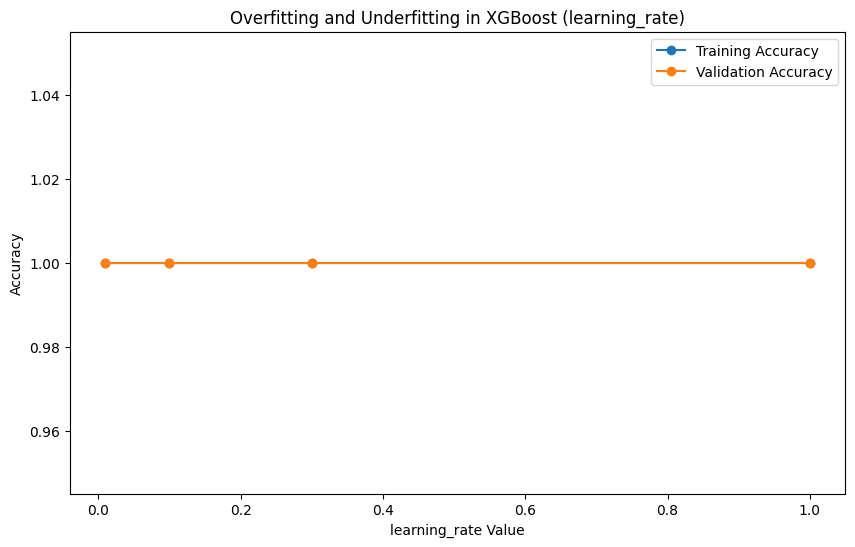

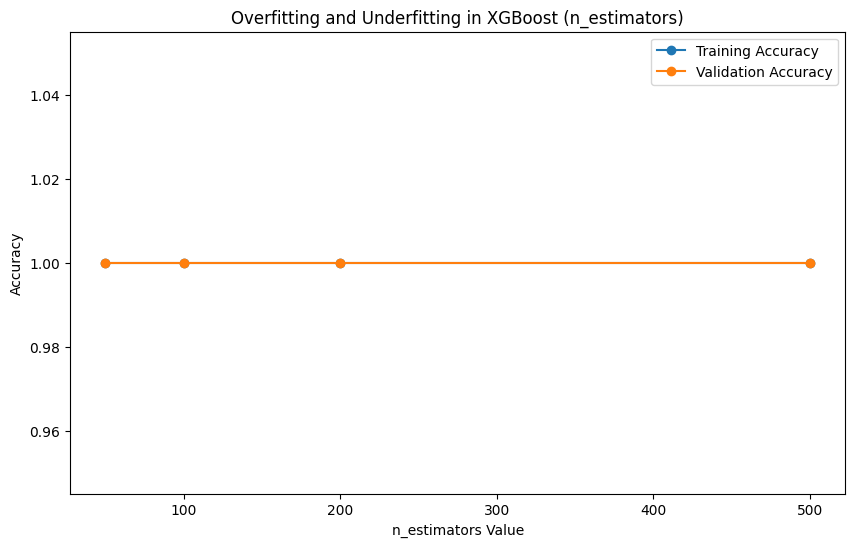

```python
from xgboost import XGBClassifier

# Splitting the dataset
X_train, X_test, y_train, y_test = train_test_split(X, y, test_size=0.2, random_state=42)

# Function to plot overfitting and underfitting with hyperparameter tuning
def plot_overfitting_underfitting(X_train, y_train, X_test, y_test, param_grid, param_name):
    train_errors = []
    test_errors = []

    for param_value in param_grid:
        model = XGBClassifier(max_depth=10, **{param_name: param_value}, random_state=42)
        model.fit(X_train, y_train)

        # Predictions
        y_train_pred = model.predict(X_train)
        y_test_pred = model.predict(X_test)

        # Calculate errors (accuracy)
        train_errors.append(accuracy_score(y_train, y_train_pred))
        test_errors.append(accuracy_score(y_test, y_test_pred))

    # Plotting the errors
    plt.figure(figsize=(10, 6))
    plt.plot(param_grid, train_errors, label='Training Accuracy', marker='o')
    plt.plot(param_grid, test_errors, label='Validation Accuracy', marker='o')
    plt.xlabel(f'{param_name} Value')
    plt.ylabel('Accuracy')
    plt.title(f'Overfitting and Underfitting in XGBoost ({param_name})')
    plt.legend()
    plt.show()

# Example: Tuning 'learning_rate'
param_grid = [0.01, 0.1, 0.3, 1.0]
plot_overfitting_underfitting(X_train, y_train, X_test, y_test, param_grid, 'learning_rate')

# Example: Tuning 'n_estimators'
param_grid = [50, 100, 200, 500]
plot_overfitting_underfitting(X_train, y_train, X_test, y_test, param_grid, 'n_estimators')
```

[output not shown]

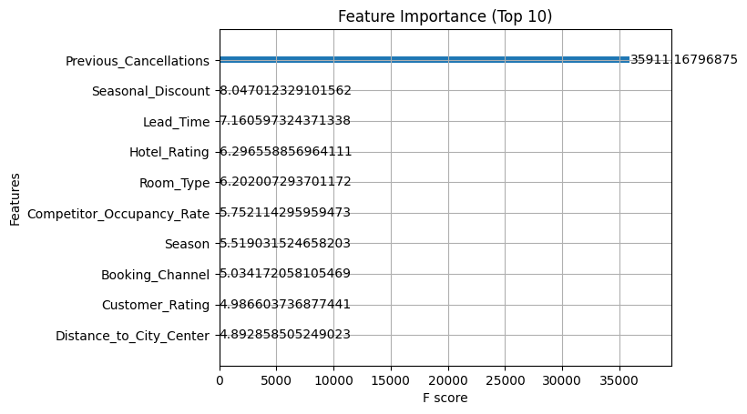

```python
from xgboost import XGBClassifier, plot_importance
from sklearn.model_selection import train_test_split, GridSearchCV
from sklearn.metrics import accuracy_score, roc_auc_score

# Splitting the dataset (Ensure X and y are defined and preprocessed properly)
X_train, X_test, y_train, y_test = train_test_split(X, y, test_size=0.2, random_state=42)

# Define XGBoost Classifier
xgb_model = XGBClassifier(objective='binary:logistic', use_label_encoder=False, random_state=42)

# Define Hyperparameter Grid
param_grid = {
    'n_estimators': [50, 100, 200],
    'max_depth': [3, 5, 7],
    'learning_rate': [0.01, 0.1, 0.3],
    'subsample': [0.8, 1.0],
    'colsample_bytree': [0.8, 1.0],
    'gamma': [0, 1],
    'min_child_weight': [1, 3]
}

# Perform Grid Search with Cross-Validation
grid_search = GridSearchCV(estimator=xgb_model, param_grid=param_grid,
                           scoring='roc_auc', cv=5, verbose=2, n_jobs=-1)
grid_search.fit(X_train, y_train)

# Extract Best Parameters
best_params = grid_search.best_params_
print("Best Hyperparameters:", best_params)

# Train Final Model with Best Parameters
best_xgb_model = XGBClassifier(**best_params, use_label_encoder=False, random_state=42)
best_xgb_model.fit(X_train, y_train)

# Predictions
y_train_pred = best_xgb_model.predict(X_train)
y_test_pred = best_xgb_model.predict(X_test)
y_train_prob = best_xgb_model.predict_proba(X_train)[:, 1]
y_test_prob = best_xgb_model.predict_proba(X_test)[:, 1]

# Evaluate Performance
train_accuracy = accuracy_score(y_train, y_train_pred)
test_accuracy = accuracy_score(y_test, y_test_pred)
train_auc = roc_auc_score(y_train, y_train_prob)
test_auc = roc_auc_score(y_test, y_test_prob)

print(f"Training Accuracy: {train_accuracy:.3f}, AUC: {train_auc:.3f}")
print(f"Testing Accuracy: {test_accuracy:.3f}, AUC: {test_auc:.3f}")

# Evaluate Underfitting and Overfitting (Adapted for Classification)
threshold = 0.05  # Adjust threshold based on the problem domain
if abs(train_auc - test_auc) > threshold:
    if train_auc > test_auc:
        print("The model is overfitting. Consider regularization (e.g., increase gamma) or reducing model complexity.")
    else:
        print("The model is underfitting. Increase model complexity (e.g., deeper trees, more estimators).")
else:
    print("The model is performing well on both training and testing data.")

# Plot Feature Importance
plt.figure(figsize=(10, 6))
plot_importance(best_xgb_model, importance_type='gain', max_num_features=10)
plt.title("Feature Importance (Top 10)")
plt.show()
```

### Customer Segmentation (Clustering)

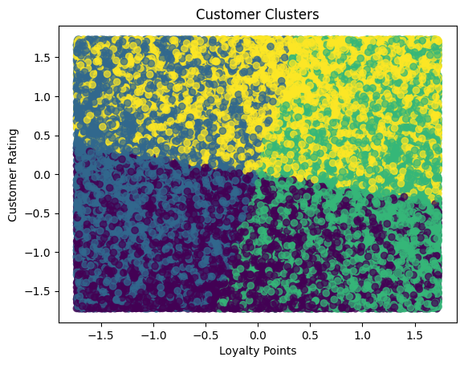

```python
from sklearn.cluster import KMeans

# Select relevant features
clustering_features = ['Loyalty_Points', 'Customer_Rating', 'Hotel_Rating']
X = df[clustering_features]

# Standardize the features
scaler = StandardScaler()
X_scaled = scaler.fit_transform(X)

# Apply K-Means Clustering
kmeans = KMeans(n_clusters=4, random_state=42)
clusters = kmeans.fit_predict(X_scaled)

# Add cluster labels to the dataset
df['Customer_Cluster'] = clusters

# Visualize the clusters
plt.scatter(X_scaled[:, 0], X_scaled[:, 1], c=clusters, cmap='viridis', alpha=0.7)
plt.title('Customer Clusters')
plt.xlabel('Loyalty Points')
plt.ylabel('Customer Rating')
plt.show()
```

### Booking Pattern Clustering (Unsupervised Learning)

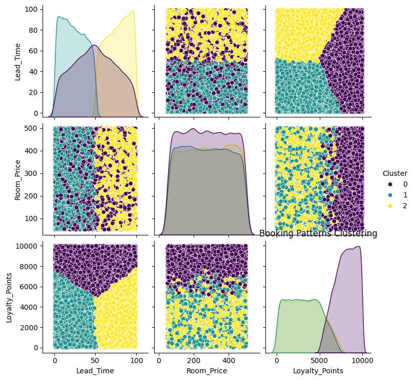

```python
from sklearn.cluster import KMeans
from sklearn.preprocessing import StandardScaler

# Select relevant features
features = ['Lead_Time', 'Room_Price', 'Loyalty_Points']
X = df[features]

# Standardize the features
scaler = StandardScaler()
X_scaled = scaler.fit_transform(X)

# Apply KMeans clustering
kmeans = KMeans(n_clusters=3, random_state=42)
clusters = kmeans.fit_predict(X_scaled)

# Add cluster labels to the dataset
df['Cluster'] = clusters

# Visualize clusters
sns.pairplot(df, vars=features, hue='Cluster', palette='viridis')
plt.title("Booking Patterns Clustering")
plt.show()
```

### Room Price Prediction (Regression)

- Predict room prices based on features like room type, city, season, and booking channel.

```python
# Define features and target variable
X = df.drop(columns=['Room_Price', 'Date'])
y = df['Room_Price']

# Train-test split
X_train, X_test, y_train, y_test = train_test_split(X, y, test_size=0.2, random_state=42)

# Define the model
model = RandomForestRegressor(n_estimators=100, random_state=42)

# Train the model
model.fit(X_train, y_train)

# Evaluate the model
y_pred = model.predict(X_test)
mae = mean_absolute_error(y_test, y_pred)
r2 = r2_score(y_test, y_pred)

print(f"Mean Absolute Error: {mae}")
print(f"R² Score: {r2}")
```

```
Mean Absolute Error: 113.40555942514308
R² Score: -0.014980963711454631
```

```python
# More Advance Working Sonn..!
# Notebook Project By : PRASAD JADHAV (ML-ENG)
# LinkedIn: linkedin.com/in/prasadmjadhav2 | Github: github.com/prasadmjadhav2 | Mail: prasadmjadhav6161@gmail.com
```

**Thank You!**